# simon-5501-05-slides

2025-09-23

## Topics to be covered

- What you will learn
  - Interpretation of linear regression coefficients
  - Computing linear regression in R
  - The least squares principle
  - The analysis of variance table
  - Computing the analysis of variance table in R
  - Confidence interval for the slope parameter
  - Computing confidence intervals in R
  - Your homework

## Bad joke, 1 of 4

[figure not shown]

## Bad joke, 2 of 4

[figure not shown]

## Bad joke, 3 of 4

[figure not shown]

## Bad joke, 4 of 4

[figure not shown]

## Quote from “Peggy Sue Got Married”

[figure not shown]

## Algebra formula for a straight line

- $Y=mx+b$
- $m = \Delta y / \Delta x$
- m = slope
- b = y-intercept

## Linear regression interpretation of a straight line

- The slope represents the estimated average change in Y when X increases by one unit.
- The intercept represents the estimated average value of Y when X equals zero.
- Terminology
  - X is the independent or predictor variable
  - Y is the dependent or outcome variable

## Simple regression example with interpretation, 1

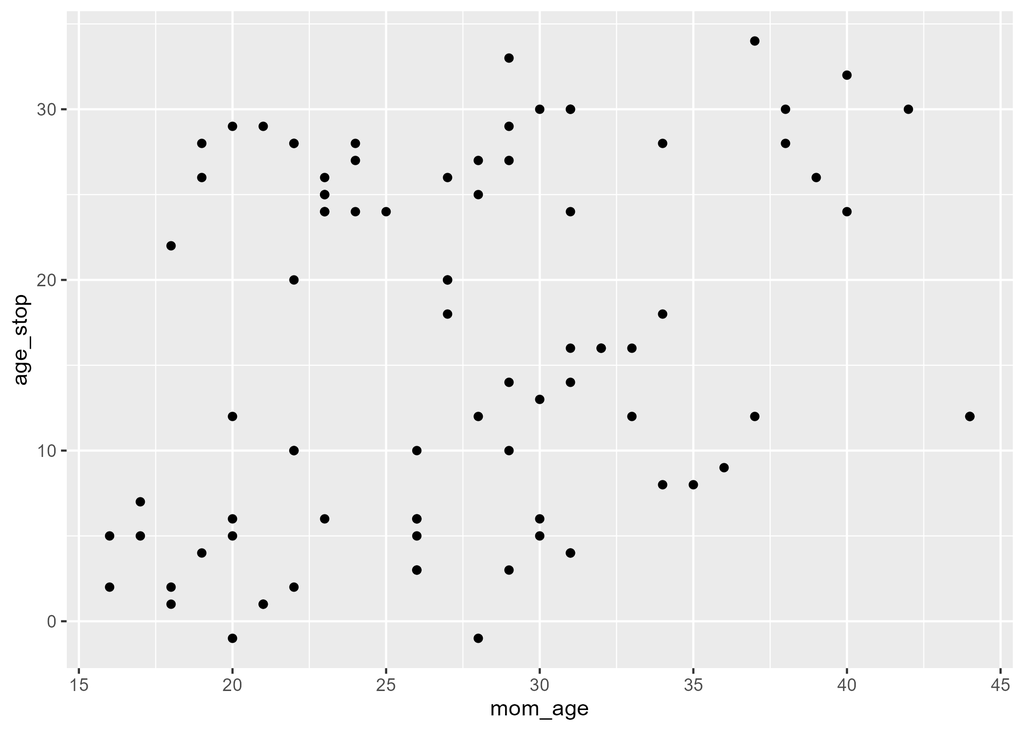

## Simple regression example with interpretation, 2

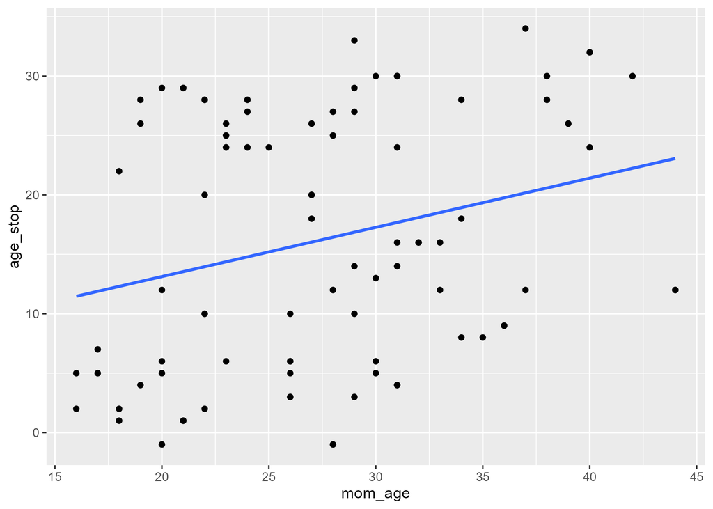

## Simple regression example with interpretation, 3

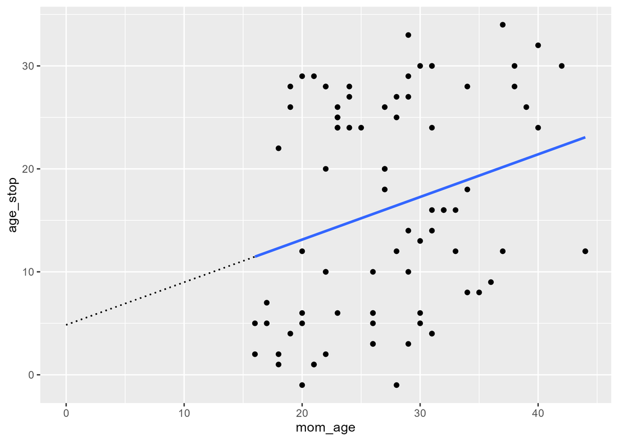

## Simple regression example with interpretation

```
Call:
lm(formula = age_stop ~ mom_age, data = bf, subset = (mom_age !=
    -1))

Coefficients:
(Intercept)      mom_age
     4.8465       0.4142
```

## Predicted values, 1

- How long would you expect a 20 year old mom to breast feed?

```
# A tibble: 5 × 2
  mom_age age_stop
    <dbl>    <dbl>
1      20        5
2      20       29
3      20        6
4      20       -1
5      20       12
```

## Predicted values, 2

- For an existing value in the data, $X_i$
  - $\hat{Y}_i=b_0+b_1 X_i$
- For a new value of X
  - $\hat{Y}_{new}=b_0+b_1 X_{new}$
  - Do not predict outside the range of X values

## Why predict for a value you already have seen?

- Future Y may differ from previous Y
- $\hat{Y}_i$ is more precise
- Comparison of $\hat{Y}_i$ to existing $Y_i$.

## Predicted values, 3

```
# A tibble: 1 × 2
  mom_age .fitted
    <dbl>   <dbl>
1      20    13.1
```

## Residuals, 1

- $e_i=Y_i-\hat{Y}_i$
  - Residual = Observed - Predicted
- Very helpful in assessing assumptions

## Residuals, 2

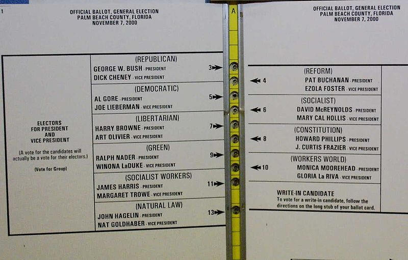

## Residuals, 3

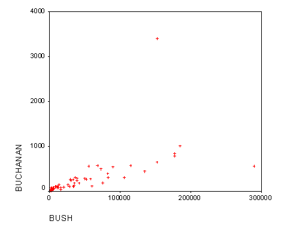

## Residuals, 4

- Votes (Buchanan) = 45.3 +0.0049 * Votes (Bush)
  - The estimated average number of votes for Buchanan increase by 1/200 for every increase of one vote for Bush.

## Residuals, 5

- In Palm Beach County
  - Votes (Bush) = 152,846
  - Predicted Votes (Buchanan) = 797
    - 45 + 0.0049 * 152,846
  - Actual Votes (Buchanan) = 3,407
- Residual = 3,407 - 797 = 2,610

## Residuals, 6

```
# A tibble: 5 × 4
  mom_age age_stop .fitted .resid
    <dbl>    <dbl>   <dbl>  <dbl>
1      20        5    13.1  -8.13
2      20       29    13.1  15.9
3      20        6    13.1  -7.13
4      20       -1    13.1 -14.1
5      20       12    13.1  -1.13
```

## Break #1

- What you have learned
  - Interpretation of linear regression coefficients
- What’s coming next
  - Computing linear regression in R

## Location of data dictionary and code

- breast-feeding-preterm.yaml
- simon-5501-05-bf.qmd

## Break #2

- What you have learned
  - Computing linear regression in R
- What’s coming next
  - The least squares principle

## The population model

- $Y_i=\beta_0+\beta_1 X_i + \epsilon_i,\ i=1,...,N$
  - $\epsilon_i$ is an unknown random variable
    - Mean 0, standard deviation, $\sigma$
    - Often assumed to be normal
  - $\beta_0$ and $\beta_1$ are unknown parameters
  - $b_0$ and $b_1$ are estimates from the sample

## Least squares principle, 1

- Collect a sample
  - $(X_1,Y_1),\ (X_2,Y_2),\ ...\ (X_n,Y_n)$
- Compute residuals
  - $e_i=Y_i-(b_0+b_1*X_i)$
  - Choose b_0 and b_1 to minimize $\Sigma e_i^2$

## Least squares principle, 2

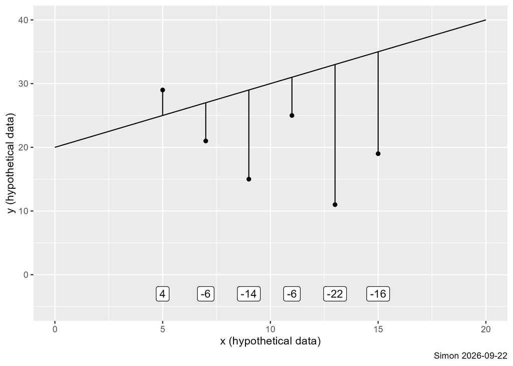

## Least squares principle, 3

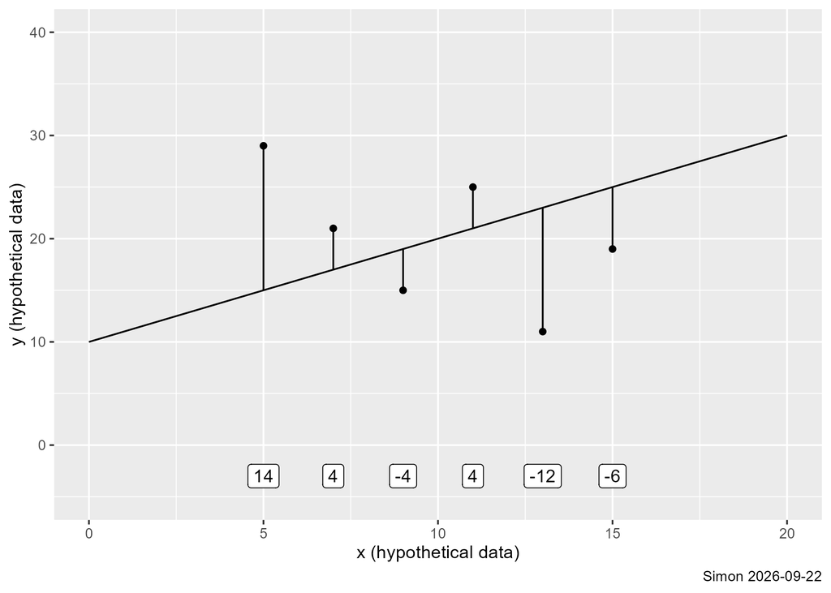

## Least squares principle, 4

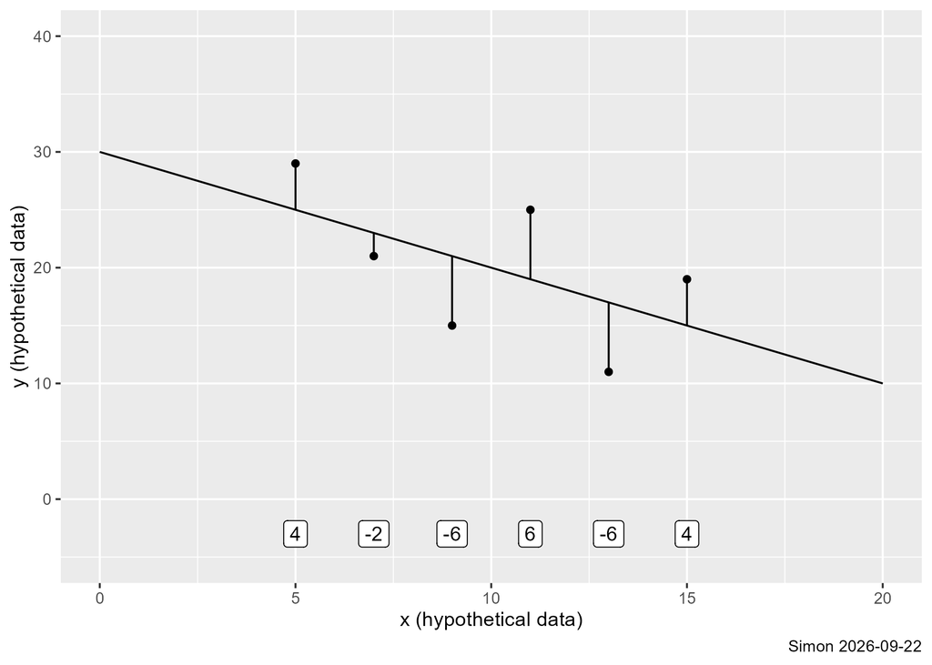

## Least squares principle, 5

- General solution
  - $b_1=\frac{\Sigma(X_i-\bar{X})(Y_i-\bar{Y})}{\Sigma(X_i-\bar{X})^2}$
  - $b_0=\bar{Y}-b_1\bar{X}$
- Notice the similarity between $b_1$ and r
  - $b_1=r\frac{S_Y}{S_X}$

## Relationship to the correlation coefficient

- Recall from the previous module
  - $Cov(X,Y)=\frac{1}{n-1}\Sigma(X_i-\bar{X})(Y_i-\bar{Y})$
  - $r_{XY}=\frac{Cov(X,Y)}{S_X S_Y}$
- This implies that
  - $b_1=r_{XY}\frac{S_Y}{S_X}$

## Important implications

- $r_{XY}$ is unitless, $b_1$ is Y units per X units
- $r_{XY}>0$ implies $b_1>0$
- $r_{XY}=0$ implies $b_1=0$
- $r_{XY}<0$ implies $b_1<0$
  - and vice versa

## Break #3

- What you have learned
  - The least squares principle
- What’s coming next
  - The analysis of variance table

## Sum of squares regression, 1

- Variation in the predicted values
  - $SS_{regression} = \Sigma(\hat{Y}_i - \bar{Y})^2$
  - Sometimes abbreviated as SSR

## Sum of squares regression, 2

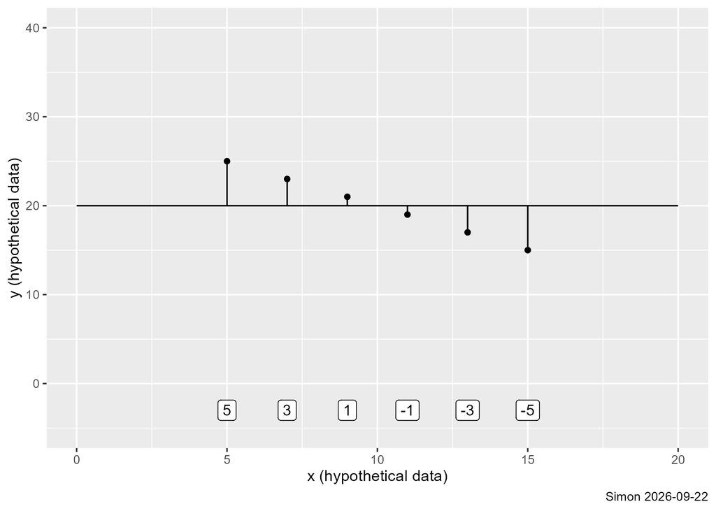

## Sum of squares error, 1

- Variation in the residuals values
  - $SS_{error} = \Sigma(\hat{Y}_i - Y_i)^2$
  - Sometimes called $SS_{residual}$
  - Sometimes abbreviated as SSE

## Sum of squares error, 2

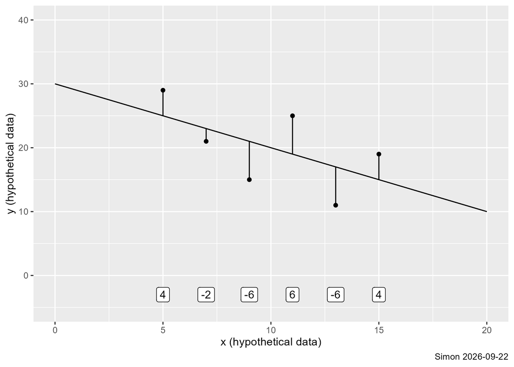

## Sum of squares total / corrected total, 1

- Variation in the predicted values
  - $SS_{total} = \Sigma(Y_i - \bar{Y})^2$
  - Sometimes abbreviated as SST

## Sum of squares total / corrected total, 2

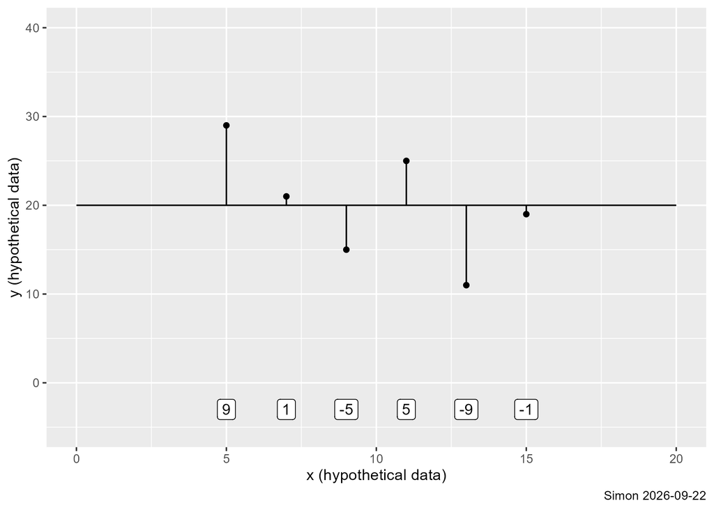

## Sum of squares total (uncorrected), 1

- Variation in the predicted values
  - $SS_{uncorrected total} = \Sigma Y_i^2$

## Sum of squares total (uncorrected), 2

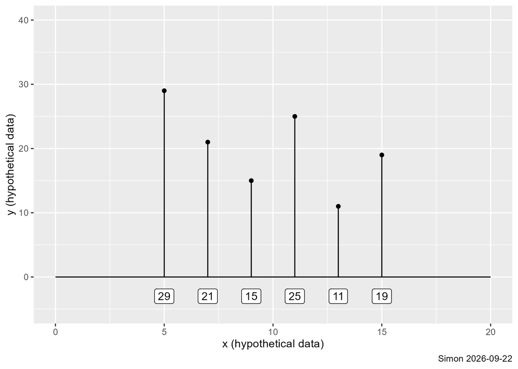

## ANOVA table for linear regression

$$\begin{matrix}
& SS & df & MS & F-ratio \\
Regression & SSR & 1 & MSR=\frac{SSR}{1} & F=\frac{MSR}{MSE} \\
Error & SSE & n-2 & MSE=\frac{SSE}{n-2} & \\
Total & SST & n-1 & &
\end{matrix}$$

## Analysis of variance table in R

```
Analysis of Variance Table

Response: age_stop
          Df Sum Sq Mean Sq F value  Pr(>F)
mom_age    1  655.3  655.33  6.3636 0.01358 *
Residuals 82 8444.3  102.98
---
Signif. codes:  0 '***' 0.001 '**' 0.01 '*' 0.05 '.' 0.1 ' ' 1
```

## R-squared

- SST, total variation, is split into
  - SSR, explained variation, and
  - SSE, unexplained variation
- $R^2=\frac{SSR}{SST}=1-\frac{SSE}{SST}$
  - $0 < R^2 < 1$
  - Proportion of explained variation
    - $R^2 > 0.5$ strong
    - $0.1 < R^2 < 0.5$ weak
- $R^2 = r^2$

## F-ratio

- $F = \frac{MSR}{MSE}$

## Break #4

- What you have learned
  - The analysis of variance table
- What’s coming next
  - Computing the analysis of variance table in R

## Location of code

- [simon-5501-05-demo.qmd](https://github.com/pmean/classes/blob/master/biostats-1/05/src/simon-5501-05-bf.qmd)

## Break #5

- What you have learned
  - Computing the analysis of variance table in R
- What’s coming next
  - Confidence interval for the slope parameter

## Confidence intervals, 1

- Population model
  - $Y_i=\beta_0+\beta_1 X_i + \epsilon_i,\ i=1,...,N$
- Sample estimates
  - $b_1=\frac{\Sigma(X_i-\bar{X})(Y_i-\bar{Y})}{\Sigma(X_i-\bar{X})^2}$
  - $b_0=\bar{Y}-b_1\bar{X}$

## Confidence intervals, 2

- Standard error (se)
  - $se(b_1)=\sqrt{\frac{MSE}{(n-1) S_x^2}}$
- Confidence interval for $\beta_1$
  - $b_1 \pm t\ se(b_1)$

## Confidence intervals, 3

```
                  2.5 %    97.5 %
(Intercept) -4.34814021 14.041213
mom_age      0.08755521  0.740747
```

## Hypothesis test, 1

- $H_0:\ \beta_1=0$
- $H_1:\ \beta_1 \ne 0$
  - Accept $H_0$ if $T=\frac{b_1}{se(b_1)}$ is close to zero
  - $\$ or Accept $H_0$ if the confidence interval includes zero
  - $\$ or Accept $H_0$ if the p-value is large

## Hypothesis test, 2

```
# A tibble: 2 × 5
  term        estimate std.error statistic p.value
  <chr>          <dbl>     <dbl>     <dbl>   <dbl>
1 (Intercept)    4.85      4.62       1.05  0.297
2 mom_age        0.414     0.164      2.52  0.0136
```

## Why two different ways to test?

- $F=T^2$
  - Accept $H_0$ if F is close to one
  - Accept $H_0$ if T is close to zero
- For both tests
  - Accept $H_0$ if p-value is large
- F and T differ in more complex settings
  - F is a global test of all variables
  - T is series of separate tests of individual variables

## Break #6

- What you have learned
  - Confidence interval for the slope parameter
- What’s coming next
  - Computing confidence intervals in R

## Location of code

- [simon-5501-05-demo.qmd](https://github.com/pmean/classes/blob/master/biostats-1/05/src/simon-5501-05-bf.qmd)

## Break #6

- What you have learned
  - Computing confidence intervals in R
- What’s coming next
  - Your homework

## Location of programming assignment

- simon-5501-05-directions.md

## Summary

- What you have learned
  - Interpretation of linear regression coefficients
  - Computing linear regression in R
  - The least squares principle
  - The analysis of variance table
  - Computing the analysis of variance table in R
  - Confidence interval for the slope parameter
  - Computing confidence intervals in R
  - Your homework